# Bellabeat Study Case

Isabela Siqueira

15/08/2021

### About this project

1. What are some trends in smart device usage?
2. How could these trends apply to Bellabeat customers?
3. How could these trends help influence Bellabeat marketing strategy?

#### The Bellabeat

[Bellabeat](https://bellabeat.com/about/) is a a high-tech company that manufactures health-focused smart products. their products are main focused in tracking activity, sleep , water intake, stress and menstrual cycles of their clients. Since the main target of marketing strategies are based in social media (Facebook, Instagram, Youtube and Twitter) it’s key to understand how useful the data collected by smart devices are to their public.

#### The Data

The data is a public data set that explores around 30 users daily habits and is decribed by the publisher in Kaggle:

[FitBit Fitness Tracker Data](https://www.kaggle.com/arashnic/fitbit) (CC0: Public Domain, dataset made available through [Mobius](https://www.kaggle.com/arashnic)): This Kaggle data set contains personal fitness tracker from thirty fitbit users. Thirty eligible Fitbit users consented to the submission of personal tracker data, including minute-level output for physical activity, heart rate, and sleep monitoring. It includes information about daily activity, steps, and heart rate that can be used to explore users’ habits.

**Possible Problems**

The data as it’s presented, doesn’t have information about age or sex, so it can be biased. The weight information can be added manually so it could contain human error.

### Starting the EDA

For these analysis we will use R. We will start by taking a look at the datasets that integrates the daily activities, sleep, weight and heart rate.

```r
# Loading the packages we will use
library(tidyverse, warn.conflicts = FALSE)
library(janitor)
library(here)
library(glue)
library(lubridate)
```

## Data Fisrt Look

Let’s check how many files we have at our disposal.

```r
# Let's check how many files we have

list.files('./Fitabase')
```

```
##  [1] "dailyActivity_merged.csv"           "dailyCalories_merged.csv"
##  [3] "dailyIntensities_merged.csv"        "dailySteps_merged.csv"
##  [5] "heartrate_seconds_merged.csv"       "hourlyCalories_merged.csv"
##  [7] "hourlyIntensities_merged.csv"       "hourlySteps_merged.csv"
##  [9] "minuteCaloriesNarrow_merged.csv"    "minuteCaloriesWide_merged.csv"
## [11] "minuteIntensitiesNarrow_merged.csv" "minuteIntensitiesWide_merged.csv"
## [13] "minuteMETsNarrow_merged.csv"        "minuteSleep_merged.csv"
## [15] "minuteStepsNarrow_merged.csv"       "minuteStepsWide_merged.csv"
## [17] "sleepDay_merged.csv"                "weightLogInfo_merged.csv"
```

The files are divided by time units, except for weight that may be a manual log entry. The file named dailyActivity contains all the daily data in one single file.

To begin our analysis, let’s take a look at the daily information, sleep and weight files:

```r
dailyActivity <- read_csv('./Fitabase/dailyActivity_merged.csv')
sleepDay <- read_csv('./Fitabase/sleepDay_merged.csv')
weightInfo <- read_csv('./Fitabase/weightLogInfo_merged.csv')
heartRate <- read_csv('./Fitabase/heartrate_seconds_merged.csv')
```

To find out how many unique participants we have in each dataset, we will count the number of distinct Ids present in the data.

```r
n_distinct(sleepDay$Id)
```

```
## [1] 24
```

```r
n_distinct(weightInfo$Id)
```

```
## [1] 8
```

```r
n_distinct(dailyActivity$Id)
```

```
## [1] 33
```

```r
n_distinct(heartRate$Id)
```

```
## [1] 14
```

```r
str(dailyActivity)
```

```
## spec_tbl_df [940 x 15] (S3: spec_tbl_df/tbl_df/tbl/data.frame)
##  $ Id                      : num [1:940] 1.5e+09 1.5e+09 1.5e+09 1.5e+09 1.5e+09 ...
##  $ ActivityDate            : chr [1:940] "4/12/2016" "4/13/2016" "4/14/2016" "4/15/2016" ...
##  $ TotalSteps              : num [1:940] 13162 10735 10460 9762 12669 ...
##  $ TotalDistance           : num [1:940] 8.5 6.97 6.74 6.28 8.16 ...
##  $ TrackerDistance         : num [1:940] 8.5 6.97 6.74 6.28 8.16 ...
##  $ LoggedActivitiesDistance: num [1:940] 0 0 0 0 0 0 0 0 0 0 ...
##  $ VeryActiveDistance      : num [1:940] 1.88 1.57 2.44 2.14 2.71 ...
##  $ ModeratelyActiveDistance: num [1:940] 0.55 0.69 0.4 1.26 0.41 ...
##  $ LightActiveDistance     : num [1:940] 6.06 4.71 3.91 2.83 5.04 ...
##  $ SedentaryActiveDistance : num [1:940] 0 0 0 0 0 0 0 0 0 0 ...
##  $ VeryActiveMinutes       : num [1:940] 25 21 30 29 36 38 42 50 28 19 ...
##  $ FairlyActiveMinutes     : num [1:940] 13 19 11 34 10 20 16 31 12 8 ...
##  $ LightlyActiveMinutes    : num [1:940] 328 217 181 209 221 164 233 264 205 211 ...
##  $ SedentaryMinutes        : num [1:940] 728 776 1218 726 773 ...
##  $ Calories                : num [1:940] 1985 1797 1776 1745 1863 ...
##  - attr(*, "spec")=
##   .. cols(
##   ..   Id = col_double(),
##   ..   ActivityDate = col_character(),
##   ..   TotalSteps = col_double(),
##   ..   TotalDistance = col_double(),
##   ..   TrackerDistance = col_double(),
##   ..   LoggedActivitiesDistance = col_double(),
##   ..   VeryActiveDistance = col_double(),
##   ..   ModeratelyActiveDistance = col_double(),
##   ..   LightActiveDistance = col_double(),
##   ..   SedentaryActiveDistance = col_double(),
##   ..   VeryActiveMinutes = col_double(),
##   ..   FairlyActiveMinutes = col_double(),
##   ..   LightlyActiveMinutes = col_double(),
##   ..   SedentaryMinutes = col_double(),
##   ..   Calories = col_double()
##   .. )
##  - attr(*, "problems")=<externalptr>
```

There is a difference in the number of unique Ids between the datasets. Since the weight dataset has fewer unique Ids we will start by merging the daily activity and the sleep datasets, this will give us an idea of the daily routine of 24 different people. We will also convert the dates from chars to date format so we can merge the dataset based on the dates.

```r
sleepDay$SleepDay <- mdy_hms(sleepDay$SleepDay)
sleepDay$SleepDay <- as.Date(sleepDay$SleepDay)
dailyActivity$ActivityDate <- mdy(dailyActivity$ActivityDate)
fitDaily <- left_join(sleepDay, dailyActivity, by=c('Id'='Id','SleepDay'='ActivityDate'))
```

Now that we have joined our data, let’s take a look at it.

```r
tibble(fitDaily)
```

```
## # A tibble: 413 x 18
##            Id SleepDay   TotalSleepRecor~ TotalMinutesAsl~ TotalTimeInBed TotalSteps
##         <dbl> <date>                <dbl>            <dbl>          <dbl>      <dbl>
##  1 1503960366 2016-04-12                1              327            346      13162
##  2 1503960366 2016-04-13                2              384            407      10735
##  3 1503960366 2016-04-15                1              412            442       9762
##  4 1503960366 2016-04-16                2              340            367      12669
##  5 1503960366 2016-04-17                1              700            712       9705
##  6 1503960366 2016-04-19                1              304            320      15506
##  7 1503960366 2016-04-20                1              360            377      10544
##  8 1503960366 2016-04-21                1              325            364       9819
##  9 1503960366 2016-04-23                1              361            384      14371
## 10 1503960366 2016-04-24                1              430            449      10039
## # ... with 403 more rows, and 12 more variables: TotalDistance <dbl>,
## #   TrackerDistance <dbl>, LoggedActivitiesDistance <dbl>,
## #   VeryActiveDistance <dbl>, ModeratelyActiveDistance <dbl>,
## #   LightActiveDistance <dbl>, SedentaryActiveDistance <dbl>,
## #   VeryActiveMinutes <dbl>, FairlyActiveMinutes <dbl>,
## #   LightlyActiveMinutes <dbl>, SedentaryMinutes <dbl>, Calories <dbl>
```

```r
str(fitDaily)
```

```
## spec_tbl_df [413 x 18] (S3: spec_tbl_df/tbl_df/tbl/data.frame)
##  $ Id                      : num [1:413] 1.5e+09 1.5e+09 1.5e+09 1.5e+09 1.5e+09 ...
##  $ SleepDay                : Date[1:413], format: "2016-04-12" "2016-04-13" ...
##  $ TotalSleepRecords       : num [1:413] 1 2 1 2 1 1 1 1 1 1 ...
##  $ TotalMinutesAsleep      : num [1:413] 327 384 412 340 700 304 360 325 361 430 ...
##  $ TotalTimeInBed          : num [1:413] 346 407 442 367 712 320 377 364 384 449 ...
##  $ TotalSteps              : num [1:413] 13162 10735 9762 12669 9705 ...
##  $ TotalDistance           : num [1:413] 8.5 6.97 6.28 8.16 6.48 ...
##  $ TrackerDistance         : num [1:413] 8.5 6.97 6.28 8.16 6.48 ...
##  $ LoggedActivitiesDistance: num [1:413] 0 0 0 0 0 0 0 0 0 0 ...
##  $ VeryActiveDistance      : num [1:413] 1.88 1.57 2.14 2.71 3.19 ...
##  $ ModeratelyActiveDistance: num [1:413] 0.55 0.69 1.26 0.41 0.78 ...
##  $ LightActiveDistance     : num [1:413] 6.06 4.71 2.83 5.04 2.51 ...
##  $ SedentaryActiveDistance : num [1:413] 0 0 0 0 0 0 0 0 0 0 ...
##  $ VeryActiveMinutes       : num [1:413] 25 21 29 36 38 50 28 19 41 39 ...
##  $ FairlyActiveMinutes     : num [1:413] 13 19 34 10 20 31 12 8 21 5 ...
##  $ LightlyActiveMinutes    : num [1:413] 328 217 209 221 164 264 205 211 262 238 ...
##  $ SedentaryMinutes        : num [1:413] 728 776 726 773 539 775 818 838 732 709 ...
##  $ Calories                : num [1:413] 1985 1797 1745 1863 1728 ...
##  - attr(*, "spec")=
##   .. cols(
##   ..   Id = col_double(),
##   ..   SleepDay = col_character(),
##   ..   TotalSleepRecords = col_double(),
##   ..   TotalMinutesAsleep = col_double(),
##   ..   TotalTimeInBed = col_double()
##   .. )
##  - attr(*, "problems")=<externalptr>
```

Since we have one entry for user Id, we can make our analysis based in each user and have a better understanding of what types of people use the FitBit with some recurrence.

To make the analysis more significant, we will filter out the Ids with at least 10 occurrences, this will help to focus more on the people that use the FitBit more often.

```r
fitDaily <- drop_na(fitDaily)
Filter_data <- fitDaily %>% group_by(Id) %>% summarise(count = n_distinct(SleepDay)) %>% filter(count>10)
fitDaily_clean <- merge(Filter_data, fitDaily, 'Id')
str(fitDaily_clean)
```

```
## 'data.frame':    379 obs. of  19 variables:
##  $ Id                      : num  1.5e+09 1.5e+09 1.5e+09 1.5e+09 1.5e+09 ...
##  $ count                   : int  25 25 25 25 25 25 25 25 25 25 ...
##  $ SleepDay                : Date, format: "2016-04-30" "2016-04-19" ...
##  $ TotalSleepRecords       : num  1 1 1 2 1 1 1 1 2 1 ...
##  $ TotalMinutesAsleep      : num  404 304 360 340 700 341 247 325 384 273 ...
##  $ TotalTimeInBed          : num  425 320 377 367 712 354 264 364 407 296 ...
##  $ TotalSteps              : num  14673 15506 10544 12669 9705 ...
##  $ TotalDistance           : num  9.25 9.88 6.68 8.16 6.48 ...
##  $ TrackerDistance         : num  9.25 9.88 6.68 8.16 6.48 ...
##  $ LoggedActivitiesDistance: num  0 0 0 0 0 0 0 0 0 0 ...
##  $ VeryActiveDistance      : num  3.56 3.53 1.96 2.71 3.19 ...
##  $ ModeratelyActiveDistance: num  1.42 1.32 0.48 0.41 0.78 ...
##  $ LightActiveDistance     : num  4.27 5.03 4.24 5.04 2.51 ...
##  $ SedentaryActiveDistance : num  0 0 0 0 0 0 0 0 0 0 ...
##  $ VeryActiveMinutes       : num  52 50 28 36 38 16 45 19 21 50 ...
##  $ FairlyActiveMinutes     : num  34 31 12 10 20 12 24 8 19 24 ...
##  $ LightlyActiveMinutes    : num  217 264 205 221 164 243 250 211 217 254 ...
##  $ SedentaryMinutes        : num  712 775 818 773 539 815 857 838 776 816 ...
##  $ Calories                : num  1947 2035 1786 1863 1728 ...
```

### Checking for trends

By applying the filter we ended up with 379 data points, we also saved the counted values for the daily entries in a separated dataset so we can use that later for some insights.

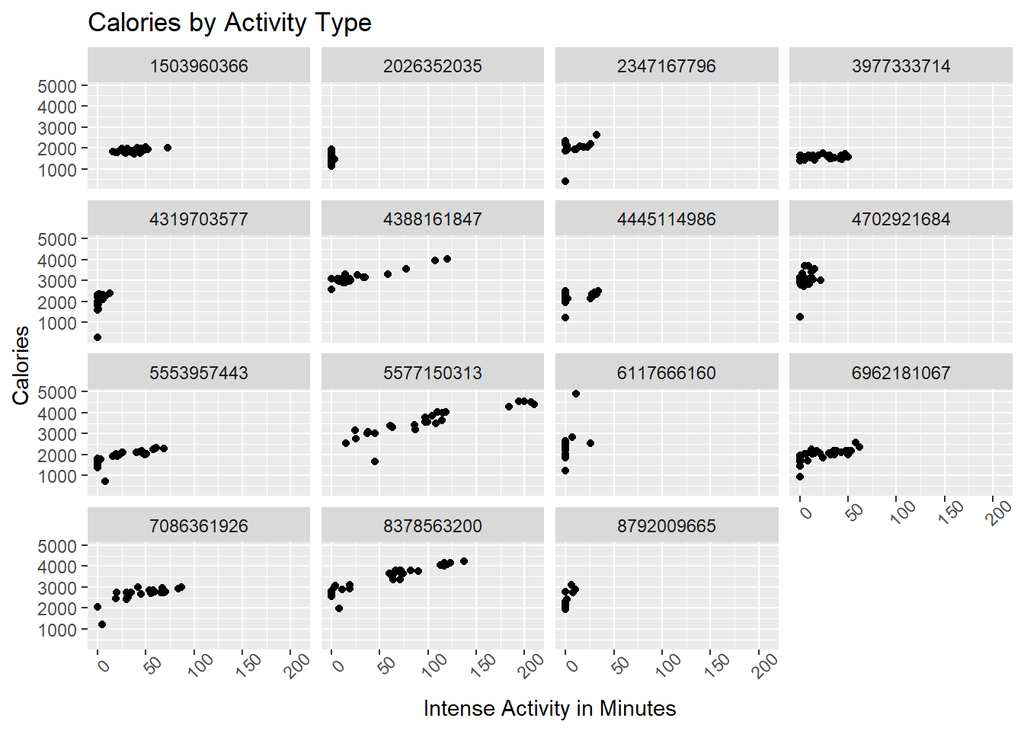

```r
fitDaily_clean$WeekDay <- weekdays(fitDaily_clean$SleepDay)
fitDaily_clean %>% ggplot(aes(VeryActiveMinutes, Calories)) + geom_point() + facet_wrap(~Id) + theme(axis.text.x = element_text(angle=45)) + labs(title = 'Calories by Activity Type', x = 'Intense Activity in Minutes')
```

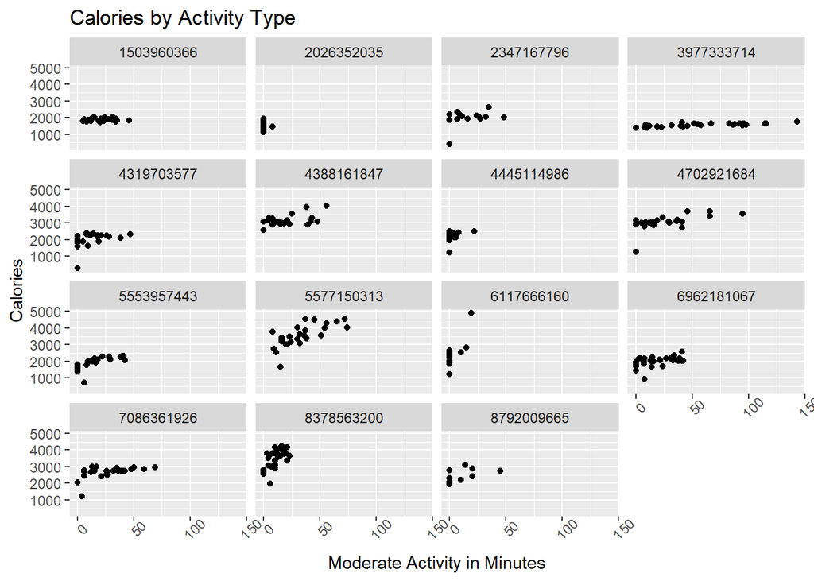

```r
fitDaily_clean %>% ggplot(aes(FairlyActiveMinutes, Calories)) + geom_point() + facet_wrap(~Id) + theme(axis.text.x = element_text(angle=45)) + labs(title = 'Calories by Activity Type', x = 'Moderate Activity in Minutes')
```

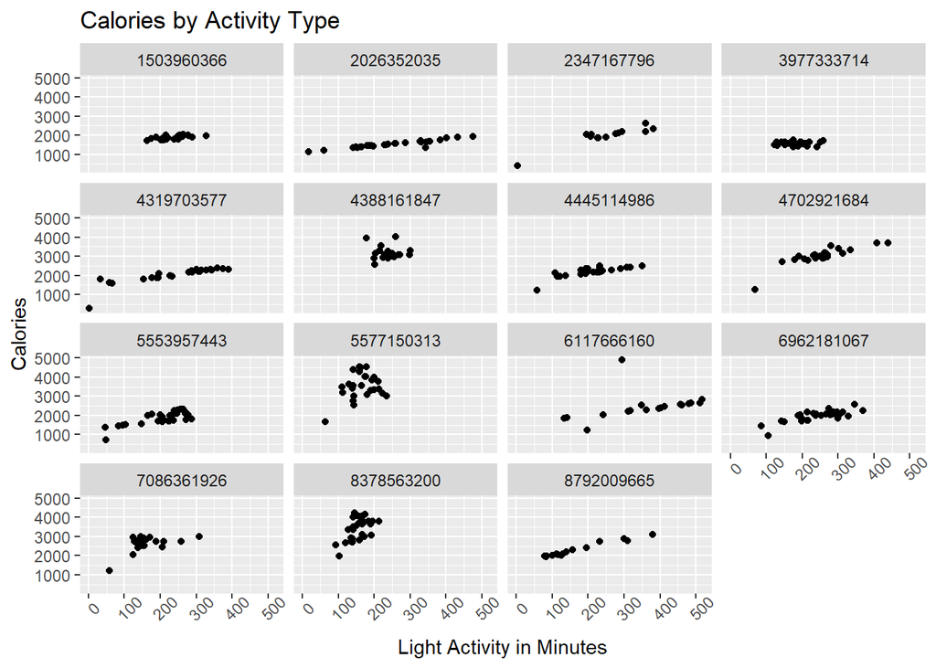

```r
fitDaily_clean %>% ggplot(aes(LightlyActiveMinutes, Calories)) + geom_point() + facet_wrap(~Id) + theme(axis.text.x = element_text(angle=45)) + labs(title = 'Calories by Activity Type', x = 'Light Activity in Minutes')
```

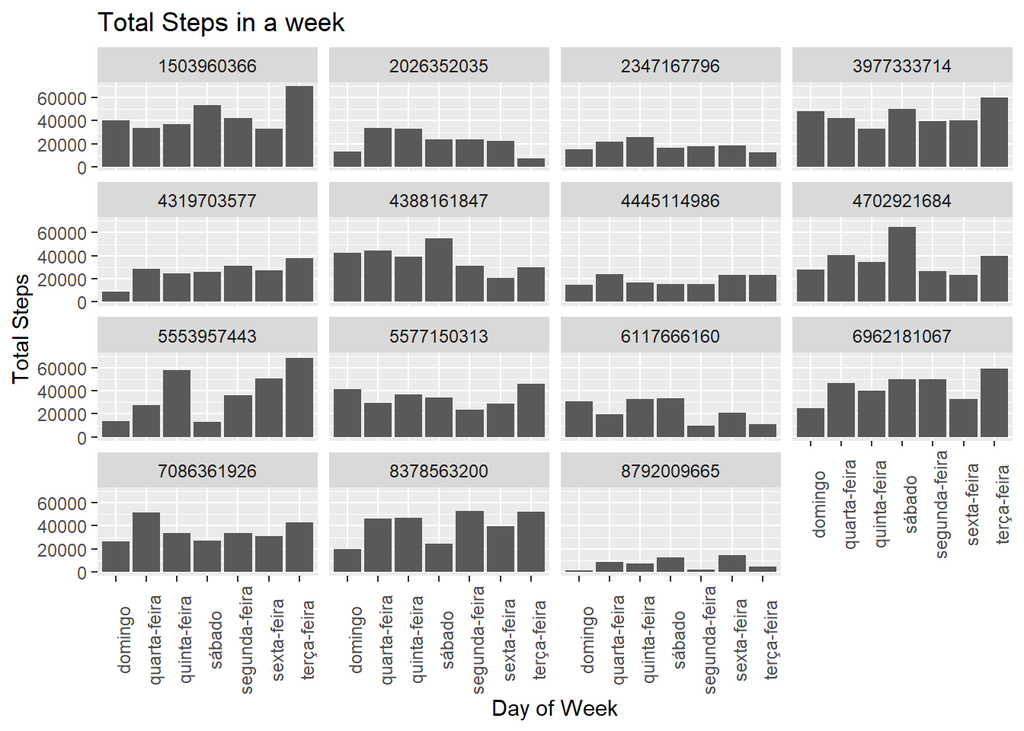

```r
fitDaily_clean %>% ggplot(aes(WeekDay, TotalSteps)) + geom_col() + facet_wrap(~Id) + theme(axis.text.x = element_text(angle=90)) + labs(title = 'Total Steps in a week', x = 'Day of Week', y='Total Steps')
```

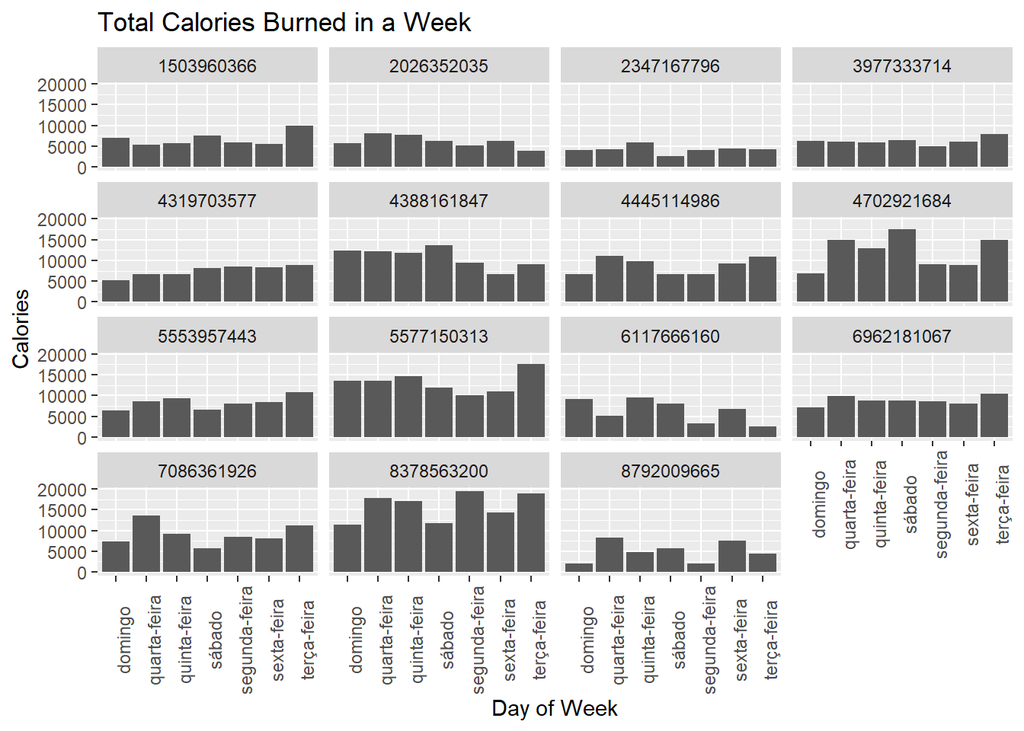

```r
fitDaily_clean %>% ggplot(aes(WeekDay, Calories)) + geom_col() + facet_wrap(~Id) + theme(axis.text.x = element_text(angle=90)) + labs(title = 'Total Calories Burned in a Week', x = 'Day of Week', y='Calories')
```

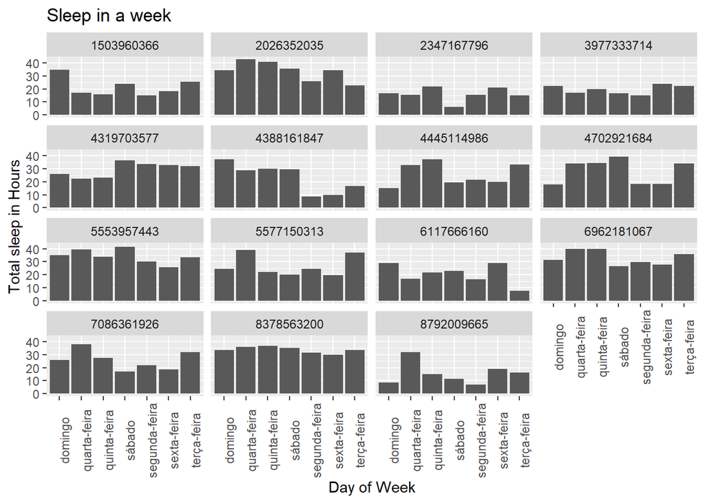

```r
fitDaily_clean$HoursAsleep <- fitDaily_clean$TotalMinutesAsleep/60
fitDaily_clean %>% ggplot(aes(WeekDay, HoursAsleep)) + geom_col() + facet_wrap(~Id) + theme(axis.text.x = element_text(angle=90)) + labs(title = 'Sleep in a week', x = 'Day of Week', y='Total sleep in Hours')
```

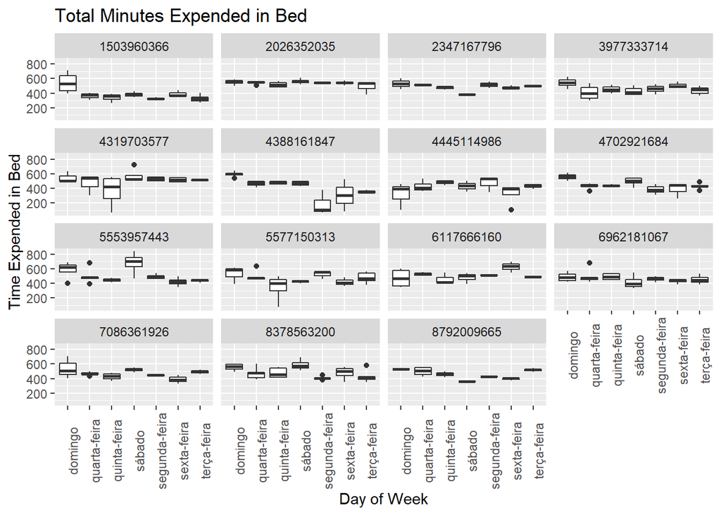

```r
fitDaily_clean %>% ggplot(aes(WeekDay, TotalTimeInBed)) + geom_boxplot() + facet_wrap(~Id) + theme(axis.text.x = element_text(angle=90)) + labs(title = 'Total Minutes Expended in Bed', x = 'Day of Week', y='Time Expended in Bed')
```